# p8105_hw5_qz2527

kindle zhang

2023-11-10

## Problem 1

- first we import the data and describe it concisely.

```r
homi_data = read_csv("./data_file/homicide-data.csv")
head(homi_data, 5)
```

```
## # A tibble: 5 × 12
##   uid   reported_date victim_last victim_first victim_race victim_age victim_sex
##   <chr>         <dbl> <chr>       <chr>        <chr>       <chr>      <chr>
## 1 Alb-…      20100504 GARCIA      JUAN         Hispanic    78         Male
## 2 Alb-…      20100216 MONTOYA     CAMERON      Hispanic    17         Male
## 3 Alb-…      20100601 SATTERFIELD VIVIANA      White       15         Female
## 4 Alb-…      20100101 MENDIOLA    CARLOS       Hispanic    32         Male
## 5 Alb-…      20100102 MULA        VIVIAN       White       72         Female
## # ℹ 5 more variables: city <chr>, state <chr>, lat <dbl>, lon <dbl>,
## #   disposition <chr>
```

```r
summary(homi_data)
```

```
##      uid            reported_date       victim_last        victim_first
##  Length:52179       Min.   : 20070101   Length:52179       Length:52179
##  Class :character   1st Qu.: 20100318   Class :character   Class :character
##  Mode  :character   Median : 20121216   Mode  :character   Mode  :character
##                     Mean   : 20130899
##                     3rd Qu.: 20150911
##                     Max.   :201511105
##
##  victim_race         victim_age         victim_sex            city
##  Length:52179       Length:52179       Length:52179       Length:52179
##  Class :character   Class :character   Class :character   Class :character
##  Mode  :character   Mode  :character   Mode  :character   Mode  :character
##
##
##
##
##     state                lat             lon          disposition
##  Length:52179       Min.   :25.73   Min.   :-122.51   Length:52179
##  Class :character   1st Qu.:33.77   1st Qu.: -96.00   Class :character
##  Mode  :character   Median :38.52   Median : -87.71   Mode  :character
##                     Mean   :37.03   Mean   : -91.47
##                     3rd Qu.:40.03   3rd Qu.: -81.76
##                     Max.   :45.05   Max.   : -71.01
##                     NA's   :60      NA's   :60
```

This is a dataset with a 52179rows and a 12 variables. It includes the homicides events’ details, like victim’s name, report date, the location where the accident occures and so on.

- tidy the data and make a series of operation upon it

```r
homi_data =
  homi_data |>
  janitor::clean_names() |>
  mutate(city_state = str_c(city, ", ", state))

homi_by_city =
  homi_data |>
  drop_na(disposition) |>
  group_by(city_state) |>
  mutate(
    unsolved_homi = case_match(
      disposition,
      "Closed without arrest" ~ 1,
      "Open/No arrest" ~ 1,
      .default = 0
    )
  ) |>
  summarise(total_homi = n(),
            unsolved_homi = sum(unsolved_homi))

homi_by_city
```

```
## # A tibble: 51 × 3
##    city_state      total_homi unsolved_homi
##    <chr>                <int>         <dbl>
##  1 Albuquerque, NM        378           146
##  2 Atlanta, GA            973           373
##  3 Baltimore, MD         2827          1825
##  4 Baton Rouge, LA        424           196
##  5 Birmingham, AL         800           347
##  6 Boston, MA             614           310
##  7 Buffalo, NY            521           319
##  8 Charlotte, NC          687           206
##  9 Chicago, IL           5535          4073
## 10 Cincinnati, OH         694           309
## # ℹ 41 more rows
```

according to the result gained above , we can summarize the total homicides and unsolved homicides by each city.

- use `prop.test` function to estimate the proportion of homicides that are unsolved

```r
homi_Bal =
  homi_by_city |>
    filter(city_state == "Baltimore, MD")

result_Bal =
  prop.test(
    x = homi_Bal$"unsolved_homi",
    n = homi_Bal$"total_homi",
    p = NULL,
    alternative = "two.sided"
  )

result_Bal |>
  broom::tidy() |>
  select(estimate, conf.low, conf.high) |>
  rename(esti_prop = estimate)
```

```
## # A tibble: 1 × 3
##   esti_prop conf.low conf.high
##       <dbl>    <dbl>     <dbl>
## 1     0.646    0.628     0.663
```

- loop the function for each city

```r
prop_by_city =
  homi_by_city |>
    mutate(prop_test_result =
             map2(unsolved_homi,
                  total_homi,
                  ~ prop.test(x = .x, n = .y))) |>
    mutate(estimate_result =
             map(prop_test_result, broom::tidy)) |>
    unnest(estimate_result) |>
    select(city_state, estimate, conf.low, conf.high)

head(prop_by_city)
```

```
## # A tibble: 6 × 4
##   city_state      estimate conf.low conf.high
##   <chr>              <dbl>    <dbl>     <dbl>
## 1 Albuquerque, NM    0.386    0.337     0.438
## 2 Atlanta, GA        0.383    0.353     0.415
## 3 Baltimore, MD      0.646    0.628     0.663
## 4 Baton Rouge, LA    0.462    0.414     0.511
## 5 Birmingham, AL     0.434    0.399     0.469
## 6 Boston, MA         0.505    0.465     0.545
```

- create a plot

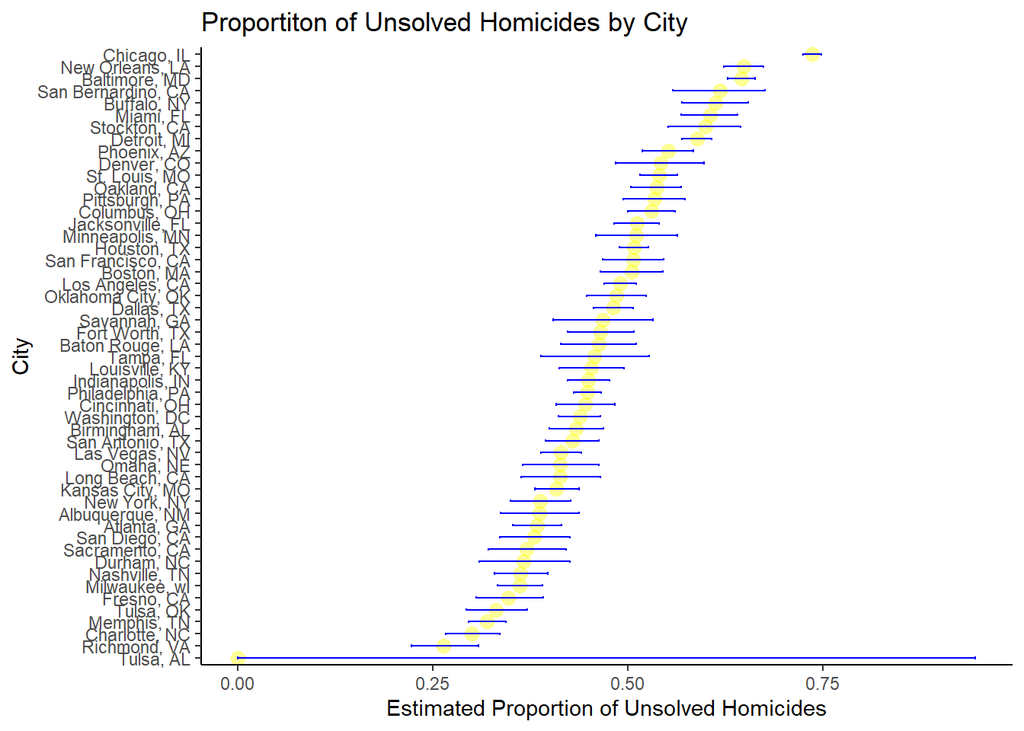

```r
plot =
  prop_by_city |>
  mutate(city_state = fct_reorder(city_state, estimate)) |>
  ggplot(aes(x = city_state, y = estimate)) + geom_point(color = "yellow",
                                                         size = 3,
                                                         alpha = .4) + geom_errorbar(aes(ymin = conf.low, ymax = conf.high),
                                                                                     width = .2,
                                                                                     color = "blue") + coord_flip() +
  theme_classic()+
  labs(title = "Proportiton of Unsolved Homicides by City",
       x = "City",
       y = "Estimated Proportion of Unsolved Homicides")

plot
```

## Problem 2

- import the data by using the function `list.files`, and then tidy it.

```r
path = "./data_file/problem_2"
id = list.files(path)
id_list = as.list(id)

new_df =
  tibble(id = id_list) |>
  mutate(address = str_c(path , "/", id),
         weekly_data = map(address, read_csv)) |>
  separate(id, into = c("arm", "other"), sep = "_") |>
  separate(other, into = c("id", "other"), sep = 2) |>
  select(-other,-address) |>
  unnest(weekly_data)
```

- show the dataset

```r
new_df |>
  knitr::kable()
```

| arm | id | week_1 | week_2 | week_3 | week_4 | week_5 | week_6 | week_7 | week_8 |
| --- | --- | --- | --- | --- | --- | --- | --- | --- | --- |
| con | 01 | 0.20 | -1.31 | 0.66 | 1.96 | 0.23 | 1.09 | 0.05 | 1.94 |
| con | 02 | 1.13 | -0.88 | 1.07 | 0.17 | -0.83 | -0.31 | 1.58 | 0.44 |
| con | 03 | 1.77 | 3.11 | 2.22 | 3.26 | 3.31 | 0.89 | 1.88 | 1.01 |
| con | 04 | 1.04 | 3.66 | 1.22 | 2.33 | 1.47 | 2.70 | 1.87 | 1.66 |
| con | 05 | 0.47 | -0.58 | -0.09 | -1.37 | -0.32 | -2.17 | 0.45 | 0.48 |
| con | 06 | 2.37 | 2.50 | 1.59 | -0.16 | 2.08 | 3.07 | 0.78 | 2.35 |
| con | 07 | 0.03 | 1.21 | 1.13 | 0.64 | 0.49 | -0.12 | -0.07 | 0.46 |
| con | 08 | -0.08 | 1.42 | 0.09 | 0.36 | 1.18 | -1.16 | 0.33 | -0.44 |
| con | 09 | 0.08 | 1.24 | 1.44 | 0.41 | 0.95 | 2.75 | 0.30 | 0.03 |
| con | 10 | 2.14 | 1.15 | 2.52 | 3.44 | 4.26 | 0.97 | 2.73 | -0.53 |
| exp | 01 | 3.05 | 3.67 | 4.84 | 5.80 | 6.33 | 5.46 | 6.38 | 5.91 |
| exp | 02 | -0.84 | 2.63 | 1.64 | 2.58 | 1.24 | 2.32 | 3.11 | 3.78 |
| exp | 03 | 2.15 | 2.08 | 1.82 | 2.84 | 3.36 | 3.61 | 3.37 | 3.74 |
| exp | 04 | -0.62 | 2.54 | 3.78 | 2.73 | 4.49 | 5.82 | 6.00 | 6.49 |
| exp | 05 | 0.70 | 3.33 | 5.34 | 5.57 | 6.90 | 6.66 | 6.24 | 6.95 |
| exp | 06 | 3.73 | 4.08 | 5.40 | 6.41 | 4.87 | 6.09 | 7.66 | 5.83 |
| exp | 07 | 1.18 | 2.35 | 1.23 | 1.17 | 2.02 | 1.61 | 3.13 | 4.88 |
| exp | 08 | 1.37 | 1.43 | 1.84 | 3.60 | 3.80 | 4.72 | 4.68 | 5.70 |
| exp | 09 | -0.40 | 1.08 | 2.66 | 2.70 | 2.80 | 2.64 | 3.51 | 3.27 |
| exp | 10 | 1.09 | 2.80 | 2.80 | 4.30 | 2.25 | 6.57 | 6.09 | 4.64 |

- make a spaghetti plot showing observations on each subject over time

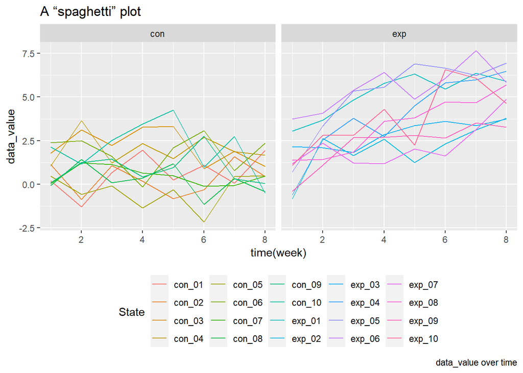

```r
new_df =
  new_df |>
    mutate(arm_id = str_c(arm, "_", id)) |>
    select( -id) |>
    relocate(arm_id) |>
  pivot_longer(
    week_1:week_8,
    names_to = "time",
    values_to = "data"
  )

plot_2 =
  new_df |>
  separate(time, into = c("week", "time"), sep = 5)|>
  mutate(time = as.numeric(time)) |>
  ggplot(aes(x = time, y = data, color = arm_id)) + geom_line() +
  facet_grid(. ~ arm) +
  labs(
    title = "A “spaghetti” plot",
    x = "time(week)",
    y = "data_value",
    color = "State",
    caption = "data_value over time"
  )+
  theme(legend.position = "bottom")

plot_2
```

We can find that the data in the control group swings in a range of -2.5 to 4 stably. The trend in the experiment group is climbing from the zero to the 7.5.

## Problem 3

- set the fix parameter

```r
n = 30
sigma = 5

list_data = vector("list", length = 5000)

for (i in 1:5000) {
  list_data[[i]] = rnorm(n = n, mean = 0, sd = sigma)

}
```

- get the dataset

```r
result_df =
  expand_grid(sample_size = n,
              iter = 1:5000) |>
  mutate(
    estimate_df = map(list_data, t.test),
    estimate_df_2 = map(estimate_df, broom::tidy)
  ) |>
  unnest(estimate_df_2) |>
  select(iter, estimate, p.value) |>
  rename(group = iter)
```

- repeat the experiment by different mean (using a function)

```r
norm_df =
  function(sample_size, sigma, mean) {
    sample_size = n
    sigma = sigma

    list_data = vector("list", length = 5000)

    for (i in 1:5000) {
      list_data[[i]] = rnorm(n = sample_size, mean = mean, sd = sigma)

    }

    result_df =
      expand_grid(sample_size = n,
                  iter = 1:5000) |>
      mutate(
        estimate_df = map(list_data, t.test),
        estimate_df_2 = map(estimate_df, broom::tidy)
      ) |>
      unnest(estimate_df_2) |>
      mutate(mean = mean) |>
      select(mean, estimate, p.value)
  }
```

- Loop the function

```r
outcome_df =
  tibble()

for (i in 0:6) {
  result = norm_df(30, 5, i)

  outcome_df = bind_rows(outcome_df, result)
}

outcome_df |>
  mutate(reject = if_else(p.value <= 0.05, 1, 0)) |>
  group_by(mean) |>
  count(reject) |>
  knitr::kable()
```

| mean | reject | n |
| --- | --- | --- |
| 0 | 0 | 4758 |
| 0 | 1 | 242 |
| 1 | 0 | 4110 |
| 1 | 1 | 890 |
| 2 | 0 | 2179 |
| 2 | 1 | 2821 |
| 3 | 0 | 572 |
| 3 | 1 | 4428 |
| 4 | 0 | 58 |
| 4 | 1 | 4942 |
| 5 | 0 | 1 |
| 5 | 1 | 4999 |
| 6 | 1 | 5000 |

- make a plot showing the rejection propitiation and the mean

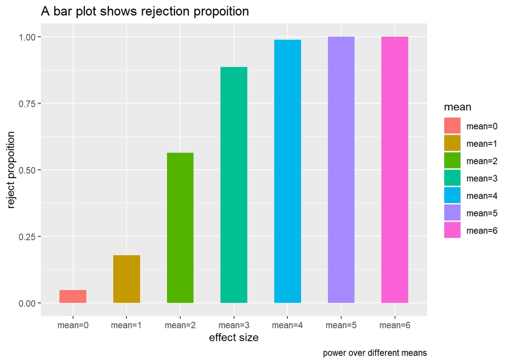

```r
outcome_df |>
  mutate(reject = if_else(p.value <= 0.05, 1, 0)) |>
  group_by(mean) |>
  summarise(n_obs = n(),
            reject_prop = sum(reject) / n()) |>
  mutate(mean = str_c("mean=", mean),
         mean = fct_inorder(mean)) |>
  ggplot(aes(x = mean, y = reject_prop, fill = mean)) + geom_bar(stat = "identity", width = 0.5) +
  labs(
    title = "A bar plot shows rejection propoition",
    x = "effect size",
    y = "reject propoition",
    color = "mean",
    caption = "power over different means"
  )
```

we can find from the table and plot that, the larger effect is, the larger power will be.

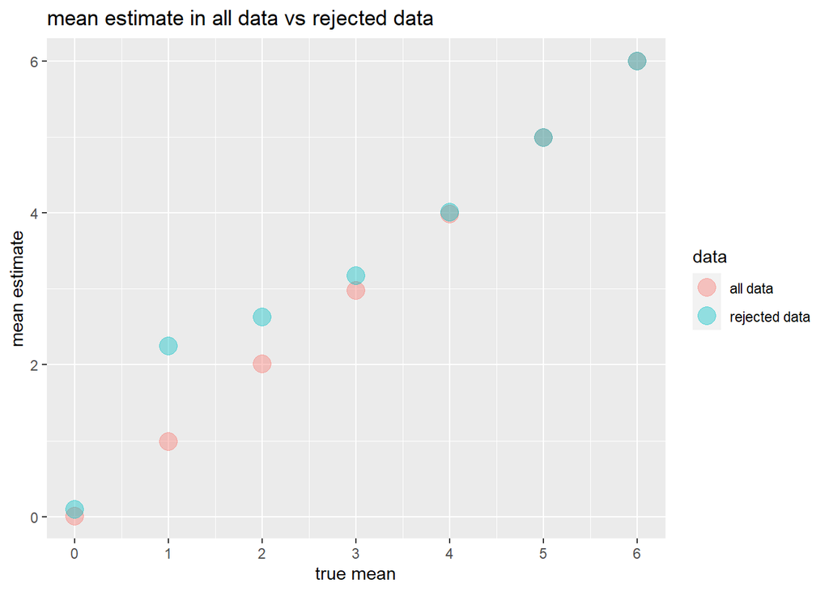

```r
outcome_df_1 =
  outcome_df |>
  group_by(mean) |>
  summarise(mean_esti = mean(estimate)) |>
  mutate(reject = "all data")

outcome_df_2 =
  outcome_df |>
  filter(p.value <= 0.05) |>
  group_by(mean) |>
  summarise(mean_esti = mean(estimate)) |>
  mutate(reject = "rejected data")

outcome_df_new = bind_rows(outcome_df_1, outcome_df_2)

plot_3 =
  outcome_df_new |>
  ggplot(aes(x = mean, y = mean_esti, color = reject)) + geom_point(alpha = .4, size = 5) + scale_x_continuous(
    breaks = c(0, 1, 2, 3, 4, 5, 6),
    labels = c("0", "1", "2", "3", "4", "5", "6")
  ) +
  labs(
    title = "mean estimate in all data vs rejected data",
    x = "true mean",
    y = "mean estimate",
    color = "data",
  )

plot_3
```

We can find that the sample average of μ^ across tests for which the null is rejected is approximately equal to the true value of μ when the true mean is larger than 4, otherwise it’s different. Because, when the effect size is bigger than 4, the difference between the whole data group and the rejected group is really small.